# BI 410 Problem Set 3

Credits: Mindy Tran Professor: Dr. Lauren Hallett DUE: 11/06/2021 *Please submit as an html file and show all your work (i.e., do NOT put echo = FALSE in your chunk)*

## 1) SPECIES RICHNESS WITH N-DEPOSITION

Check out http://www.cedarcreek.umn.edu/research/experiments/e001

#### i) What did Clark and Tilman 2008 find? See text and Figure 1

**Q: What pattern did they observe between species richness and nitrogen treatment?**

At higher N addition, diversity is lower. There was higher species richness when the amount of nitrogen in the treatment was lower. As the mass of nitrogen increased, the relative species number decreased.

**Q: What years and treatments did they include in Figure 1?**

The years included were 1982 to 2004 The treatments were 10, 34, and 95 kg of nitrogen per hectar per year.

###WORKFLOW: Mimic Figure 1 (except on the y-axis just plot species richness). Metadata here: http://www.cedarcreek.umn.edu/research/data/dataset?ple001

#### ii) Within your group, write out the workflow you will use in English and ping one of us when done.

**Data QAQC** Group by the first 7 columns and summarize the richness by the number of rows/species in that plot of land. Remove the miscellaneous litter, removing NA entries.

In class:. Remove non-species and non-species entries. (misc litter). Remove one of the control treatments for balance replication.. Remove any double counts (ex, when a line is entered twice during data entry).. Remove biomass values < 0 or NA.

**Data manipulation** Plot species richness overtime with 3 different N treatments. Group by 7 cols, then group by year and plot, measure To calculate the mean and std error, within each year We plan on using a box plot for the species richness per year. Then, we will make separate columns for the average species richness and an additional column for standard error using the below function.

In Class: . Calculate species richness within a replicate within the field, plot, year, NTrt. . Calculate the average and std error for species richness. Group by treatment/year. . Subset to keep only the years of interest, and then keep low, medium, and high to retain control.

#### iii) After we have discussed as a class, write out and run the workflow in tidyverse R.

Here’s the data import to get you going:

```r
# load the tidyverse package
library(tidyverse)
```

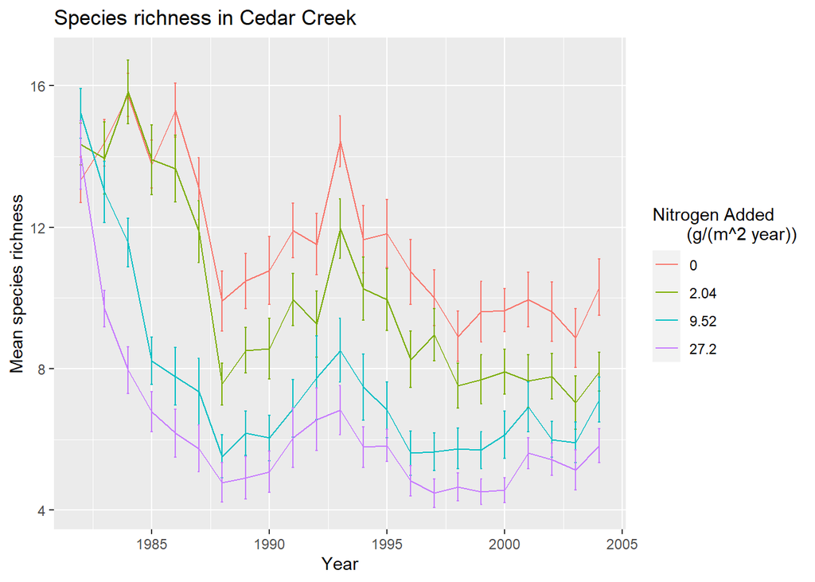

```r
# create a function to calculate standard error
calcSE<-function(x){
  x <- x[is.na(x)==F]
  sd(x)/sqrt(length(x))
}

# read in the data as tibble
cdrplant <- read_csv("e001_Plant aboveground biomass data.csv", skip = 726) %>%

## Data QAQC
  # 1. Remove non-species and non-species entries.
  filter(grepl('Miscellaneous|Fungi|Pine cones|Pine needles|', Species)) %>%
  # 2. Remove one of the control treatments for balance replication.
  filter(NTrt != 9) %>%
  # 3. Remove biomass values < 0 or NA.
  filter(!is.na(Biomass), Biomass > 0) %>%
  # 4. Remove any double counts (ex, when a line is entered twice during data entry).
  select(-Biomass) %>%
  distinct() %>%

## Data manipulation
  # 1. Calculate species richness within field, plot, year, NTrt, Nadd. Count num rows as an indicator of richness
  group_by(Field, Plot, Year, NTrt, NAdd) %>%
  count() %>%
  # 2. Calculate the average and std error for species richness. Group by treatment/year.
  group_by(NAdd, Year) %>%
  summarize(meanrich = mean(n), serich = calcSE(n)) %>%

  # 3. Subset to keep only the years of interest, and then keep low, medium, and high to retain control.
  # find at low, medium, and high: unique(cdrplant$NAdd)
  filter(Year > 1981, Year < 2005,
         NAdd == 0 | NAdd == 2.04 | NAdd == 9.52 | NAdd == 27.2)
## Graph it: Year vs meanrich, color lines by NTrt
ggplot(cdrplant, aes(x=Year, color = as.factor(NAdd))) +
  geom_line(aes(y=meanrich)) +
  geom_errorbar(aes(ymax = meanrich + serich,
                    ymin = meanrich - serich), width=.1) +
  labs(title = "Species richness in Cedar Creek",
         color = "Nitrogen Added
       (g/(m^2 year))",
       x = "Year",
       y="Mean species richness") # title and caption
```

## 2) C:N RATIOS WITH N-DEPOSITION

Check out http://www.cedarcreek.umn.edu/research/experiments/e001

#### i) What did Wedin and Tilman 1996 find? See text and Figure 7

The authors saw three things. At higher N addition, diversity is lower, C4 grasses are less abundant, and litter and root C:N ratios are lower.

### WORKFLOW: Please make a graph of the ratio of C:N in aboveground biomass in response to the amount of nitrogen added by species. Include standard error bars around each plotted point.

Unlike Wedin, these data are just from Field C, so no need to represent each field separately.  
The sample sizes for some species and N levels are very low, please only include species that have at least 4 replicates in each of at least 3 nitrogen levels. NOTE: It is okay to iteratively check this (e.g., plotting first and then identifying which species match these criteria) Metadata here: http://www.cedarcreek.umn.edu/research/data/dataset?nbe001

#### ii) Write out the workflow you will use in English.

**- What QAQC will you do beforehand?**

1. Remove values < 0 or NA.
2. Calculate the mean ratio of C:N (mutate)
- Look at it in relation to (aka group_by) amount of N and species
3. Std error bars (calcSE)
- make column of average C:N for each species in each N-level
4. Sample size is low, so include species with 4+ replicates in each 3 N-levels.
- group_by species/N-level and counting it up (add count column)
- filter: if there’s not 4+ replicates, remove it
- make sure there are 3 levels of N

**- How will you manipulate the data to create the graph?** 1. After making sure the species are separate, make a line of the C:N ratios 2. make the error bar 3. make a legend/format the graph

#### iii) Write out and run the workflow in tidyverse R.

Please comment your code. Here’s the data import to get you going (uncomment the data import):

```r
cdrCN <- read_csv("e001_Plant aboveground biomass carbon and nitrogen.csv", skip = 491) %>%
## Data QAQC
  # 1. Remove values < 0 or NA.
  filter(!is.na(`% Carbon`), `% Carbon` > 0, !is.na(`% Nitrogen`), `% Nitrogen` > 0) %>%
  unique() %>%
  # 2. Calculate the mean ratio of C:N (mutate)
  # - Look at it in relation to (aka group_by) amount of N and species
  group_by(Species, NAdd) %>%
  mutate(ratioCN = `% Carbon`/`% Nitrogen`) %>%
  # 3. Std error bars (calcSE)
  # - make column of average C:N for each species in each N-level
  mutate(mean_ratioCN = mean(ratioCN), se_ratioCN = calcSE(ratioCN)) %>%
  group_by(Species, NAdd) %>%
  # 4. Sample size is low, so include species with 4+ replicates in each 3 N-levels.
  # - group_by species/N-level and counting it up (add count column)
  add_count(Species, NAdd, name = "numReplicates") %>%
  # - filter: if there's not 4+ replicates, remove it
  filter(numReplicates >= 4) %>%
      # An aside: look at interesting info
  group_by(Species, NAdd, numReplicates, mean_ratioCN, se_ratioCN) %>%
  select() %>% unique() %>% ungroup() %>%
  unique() %>%
  # - make sure there are 3 levels of N
  group_by(Species) %>%
  add_count(name = "num_NLevels") %>%
  filter(num_NLevels >= 3) %>%
  ungroup()
# format the dataframe
cdrCN[
  order( cdrCN[,1], cdrCN[,2] ),
]
```

```
## # A tibble: 15 x 6
##    Species                NAdd numReplicates mean_ratioCN se_ratioCN num_NLevels
##    <chr>                 <dbl>         <int>        <dbl>      <dbl>       <int>
##  1 Agropyron repens       0                6         33.0      3.90            3
##  2 Agropyron repens       2.04             6         21.2      3.49            3
##  3 Agropyron repens       5.44             6         18.0      2.23            3
##  4 Artemisia ludoviciana  0                7         24.5      3.81            3
##  5 Artemisia ludoviciana  2.04             5         15.9      1.22            3
##  6 Artemisia ludoviciana  5.44             6         19.0      3.63            3
##  7 Euphorbia corolatta    0                6         22.6      3.75            3
##  8 Euphorbia corolatta    2.04             4         15.8      1.85            3
##  9 Euphorbia corolatta    5.44             5         16.3      1.37            3
## 10 Lathyrus venosus       0                6         11.2      1.24            3
## 11 Lathyrus venosus       2.04             5         12.1      1.86            3
## 12 Lathyrus venosus       5.44             5         12.6      1.23            3
## 13 Poa pratensis          0                5         31.8      3.32            3
## 14 Poa pratensis          2.04             6         20.3      0.770           3
## 15 Poa pratensis          5.44             6         16.2      0.698           3
```

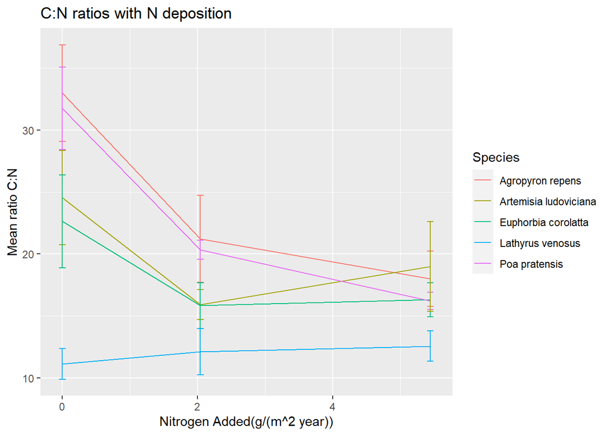

```r
## Graph it
ggplot(cdrCN, aes(x=NAdd, color = as.factor(Species))) +
  # 1. After making sure the species are separate, make a line of the C:N ratios
  geom_line(aes(y=mean_ratioCN)) +
  # 2. make the error bar
  geom_errorbar(aes(ymax = mean_ratioCN + se_ratioCN,
                    ymin = mean_ratioCN - se_ratioCN), width=.1) +
  # title and caption
  labs(title = "C:N ratios with N deposition",
         color = "Species",
       x = "Nitrogen Added(g/(m^2 year))",
       y="Mean ratio C:N")
```